# Scenario analysis for healthcare needs for COVID-19 in Georgia

Andreas Handel (ahandel@uga.edu)

March 27, 2020

## Introduction

The following produces predictions for health care needs in GA for COVID-19. The basis for this is a transmission simulation model developed and tuned by John M. Drake (jdrake@uga.edu), which is described here: http://2019-coronavirus-tracker.com/stochastic-GA.html

The transmission simulation model is run for different intervention scenarios. Output from this model is further processed here to produce estimates for health care needs in GA.

## Assumptions

Below are assumptions with high and low values for different quantities that go into the model predictions.

### Hospitalization risk

We assume that **among those that are cases (i.e. infected and tested positive)**, risk of hospitalization is as follows. This is based on (Wu and McGoogan 2020; Ferguson and al. 2020; Remuzzi and Remuzzi 2020). The first number is a low estimate, the second number a high end estimate. All values are percent.

- Under 18y: 0.10%/1.00%
- Between 18-60y: 1.00%/10.00%
- Between 60-70y: 10.00%/25.00%
- Above 70y: 20.00%/50.00%

### Critical Care Risk

We assume that **among those that are hospitalized**, risk of critical care need is as follows. This is based on (Wu and McGoogan 2020; Ferguson and al. 2020; Remuzzi and Remuzzi 2020). The first number is a low estimate, the second number a high end estimate:

- Under 18y: 1.00%/10.00%
- Between 18-60y: 5.00%/15.00%
- Between 60-70y: 20.00%/40.00%
- Above 70y: 40.00%/70.00%

### Risk of death

We assume that **among cases**, risk of death is as follows. This is based on (Verity et al. 2020). The first number is a low estimate, the second number a high end estimate:

- Under 18y: 0.005%/0.010%
- Between 18-60y: 0.10%/1.00%
- Between 60-70y: 2.00%/8.00%
- Above 70y: 5.00%/20.00%

### Length of hospital stay

We assume that a hospital stay is between 10 (low) and 20 (high) days and independent of age. This is based on (Guan et al. 2020; Tindale et al. 2020; Sanche et al. 2020).

### Lag times

The current assumption is that a case becomes hospitalized or critical 1 days after identification as a case. The lag from case identification to death is assumed to be 2 days. This reflect the situation in the early stages of the pandemic in GA. As testing ramps up, diagnosis will likely occur earlier and thus the time between diagnosis and hospitalization/death will increase. We will adjust as new data becomes available.

## Model results

Figures and Tables with predictions for different infection spread scenarios. See [here](http://2019-coronavirus-tracker.com/stochastic-GA.html) for more details on each scenario.

Results show predicted hospitalizations and critical care needs. For each variable, a low and high prediction is produced. Each variable is reported both as new individuals entering a given state (hospitalized/critical/etc.) at any given day and the total number of individuals in that state at any given date. The total hospital and critical care capacity needs for a given day take into account both new individuals entering and those leaving (due to recovery or death).

The transmission simulation is run from 2020-03-01 to 2020-04-24, this is the reporting time-frame for cases. Hospitalizations and critical care numbers are assumed to lag case ascertainment by 1 days. Death is assumed to lag by 2 days. This is likely not true during the first few weeks, when a lot of diagnoses were only made after someone had already been in the hospital, or had died. Thus, for most of March, hospitalizations and deaths on a given day might be under-predicted. We assume that going forward, as test capacity keeps increasing, most individuals will be diagnosed before hospitalization or death.

### Results for scenario 9

**Scenario description**

9. Social distancing with 555 initial infections and moderate presymptomatic transmission, step change in isolation, improving case ascertainment.

**Result Figure**

The left column show daily new individuals. The right column shows total numbers at a given date. Note that recovery of cases is not included here, thus cases keep increasing. Cases are the average predicted from the stochastic simulation model.

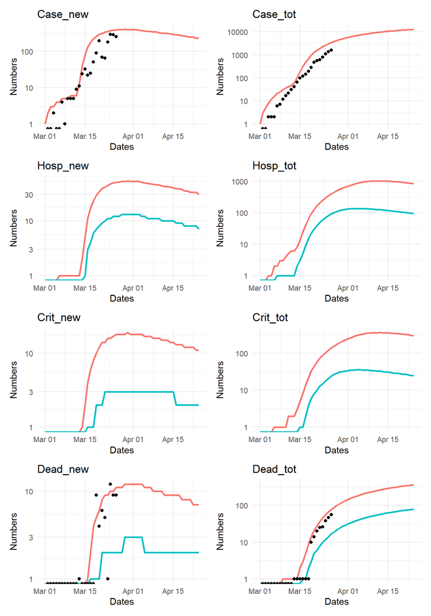

### Results for scenario 16

**Scenario description**

**Result Figure**

The left column show daily new individuals. The right column shows total numbers at a given date. Note that recovery of cases is not included here, thus cases keep increasing. Cases are the average predicted from the stochastic simulation model.

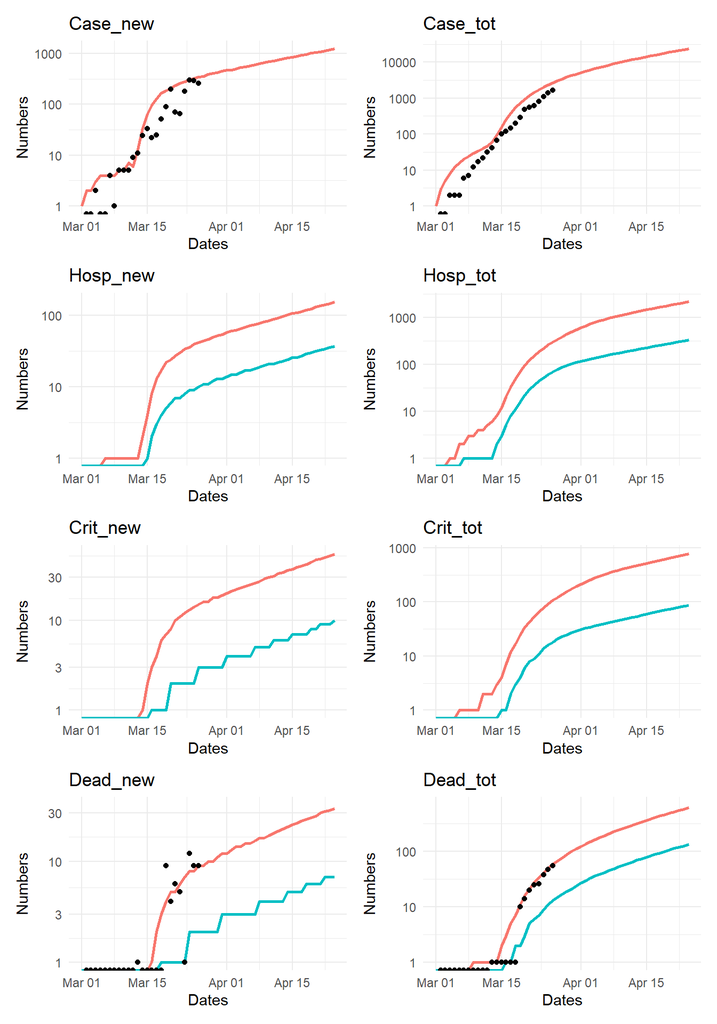

## References

Ferguson, Neil, and et al. 2020. “Report 9: Impact of Non-Pharmaceutical Interventions (Npis) to Reduce Covid-19 Mortality and Healthcare Demand.” https://www.imperial.ac.uk/mrc-global-infectious-disease-analysis/news--wuhan-coronavirus/.

Guan, Wei-jie, Zheng-yi Ni, Yu Hu, Wen-hua Liang, Chun-quan Ou, Jian-xing He, Lei Liu, et al. 2020. “Clinical Characteristics of Coronavirus Disease 2019 in China.” *New England Journal of Medicine* 0 (0): null. https://doi.org/10.1056/NEJMoa2002032.

Remuzzi, Andrea, and Giuseppe Remuzzi. 2020. “COVID-19 and Italy: What Next?” *The Lancet* 0 (0). https://doi.org/10.1016/S0140-6736(20)30627-9.

Sanche, Steven, Yen Ting Lin, Chonggang Xu, Ethan Romero-Severson, Nick Hengartner, and Ruian Ke. 2020. “The Novel Coronavirus, 2019-nCoV, Is Highly Contagious and More Infectious Than Initially Estimated.” *medRxiv*, February, 2020.02.07.20021154. https://doi.org/10.1101/2020.02.07.20021154.

Tindale, Lauren, Michelle Coombe, Jessica E. Stockdale, Emma Garlock, Wing Yin Venus Lau, Manu Saraswat, Yen-Hsiang Brian Lee, et al. 2020. “Transmission Interval Estimates Suggest Pre-Symptomatic Spread of COVID-19.” *medRxiv*, March, 2020.03.03.20029983. https://doi.org/10.1101/2020.03.03.20029983.

Verity, Robert, Lucy C. Okell, Ilaria Dorigatti, Peter Winskill, Charles Whittaker, Natsuko Imai, Gina Cuomo-Dannenburg, et al. 2020. “Estimates of the Severity of COVID-19 Disease.” *medRxiv*, March, 2020.03.09.20033357. https://doi.org/10.1101/2020.03.09.20033357.

Wu, Zunyou, and Jennifer M. McGoogan. 2020. “Characteristics of and Important Lessons from the Coronavirus Disease 2019 (COVID-19) Outbreak in China: Summary of a Report of 72 314 Cases from the Chinese Center for Disease Control and Prevention.” *JAMA*, February. https://doi.org/10.1001/jama.2020.2648.